# Assignment1

## AKINDELE DAVID AWE - 8999846

### CSCN 8010 - 24F - Sec1to2- Founcdations of Machine Learning Framework

### Framing the Problem

The goal of this report is to perform Univariate Linear Regression on the California Housing Prices Dataset and give adequate details of all the processes. By using different independent variables, we can be able predict the median house values which is our dependent variable.

```python
import pandas as pd
```

The first step towards progress is importing pandas library. Pandas is a powerful Python library that provides high-performance data structures and data analysis tools. It is particularly useful for working with tabular data, such as CSV files, Excel spreadsheets, and SQL databases. The statement above imports the Pandas library and assigns it the alias pd. This allows me to use Pandas functions and classes by prefixing them with pd.

```python
df = pd.read_csv('housing.csv')
df.head()
```

|  | longitude | latitude | housing_median_age | total_rooms | total_bedrooms | population | households | median_income | median_house_value | ocean_proximity |
| --- | --- | --- | --- | --- | --- | --- | --- | --- | --- | --- |
| 0 | -122.23 | 37.88 | 41.0 | 880.0 | 129.0 | 322.0 | 126.0 | 8.3252 | 452600.0 | NEAR BAY |
| 1 | -122.22 | 37.86 | 21.0 | 7099.0 | 1106.0 | 2401.0 | 1138.0 | 8.3014 | 358500.0 | NEAR BAY |
| 2 | -122.24 | 37.85 | 52.0 | 1467.0 | 190.0 | 496.0 | 177.0 | 7.2574 | 352100.0 | NEAR BAY |
| 3 | -122.25 | 37.85 | 52.0 | 1274.0 | 235.0 | 558.0 | 219.0 | 5.6431 | 341300.0 | NEAR BAY |
| 4 | -122.25 | 37.85 | 52.0 | 1627.0 | 280.0 | 565.0 | 259.0 | 3.8462 | 342200.0 | NEAR BAY |

The first line of code is a Pandas function used to read CSV files.\ 'housing.csv' is the path to the CSV file i want to read. The link to get a copy of the file is: [Link To Data](https://www.kaggle.com/datasets/camnugent/california-housing-prices) \ df.head() is a method that displays the first 5 rows of the DataFrame df. It's a quick way to get a preview of the data.

## Exploratory Data Analysis

An approach to analyzing data sets to summarize their main characteristics, often with visual methods.

```python
df.describe()
```

|  | longitude | latitude | housing_median_age | total_rooms | total_bedrooms | population | households | median_income | median_house_value |
| --- | --- | --- | --- | --- | --- | --- | --- | --- | --- |
| count | 20640.000000 | 20640.000000 | 20640.000000 | 20640.000000 | 20433.000000 | 20640.000000 | 20640.000000 | 20640.000000 | 20640.000000 |
| mean | -119.569704 | 35.631861 | 28.639486 | 2635.763081 | 537.870553 | 1425.476744 | 499.539680 | 3.870671 | 206855.816909 |
| std | 2.003532 | 2.135952 | 12.585558 | 2181.615252 | 421.385070 | 1132.462122 | 382.329753 | 1.899822 | 115395.615874 |
| min | -124.350000 | 32.540000 | 1.000000 | 2.000000 | 1.000000 | 3.000000 | 1.000000 | 0.499900 | 14999.000000 |
| 25% | -121.800000 | 33.930000 | 18.000000 | 1447.750000 | 296.000000 | 787.000000 | 280.000000 | 2.563400 | 119600.000000 |
| 50% | -118.490000 | 34.260000 | 29.000000 | 2127.000000 | 435.000000 | 1166.000000 | 409.000000 | 3.534800 | 179700.000000 |
| 75% | -118.010000 | 37.710000 | 37.000000 | 3148.000000 | 647.000000 | 1725.000000 | 605.000000 | 4.743250 | 264725.000000 |
| max | -114.310000 | 41.950000 | 52.000000 | 39320.000000 | 6445.000000 | 35682.000000 | 6082.000000 | 15.000100 | 500001.000000 |

df.describe() is a Pandas function that provides summary statistics of a DataFrame. It calculates various quantiles, such as the count, mean, standard deviation, minimum, 25th percentile, 50th percentile (median), 75th percentile, and maximum values for each numerical column in the DataFrame. A detailed explanation of each feature is described below: \ count: The number of non-null values in each column. \ mean: The average value of each column. \ std: The standard deviation of each column. \ min: The minimum value of each column. \ 25%: The 25th percentile of each column. \ 50%: The 50th percentile (median) of each column.\ 75%: The 75th percentile of each column. \ max: The maximum value of each column.

## Scatter Plots

Another way of performing EDA is by visualization using scatter plots. Scatter Plots are a type of graph used to visualize the relationship between two numerical variables. Each data point is represented by a dot on the graph, where the x-coordinate corresponds to the value of one variable and the y-coordinate corresponds to the value of the other variable. \ We are able to create these visualizations using the Matplotlib library and Seaborn library

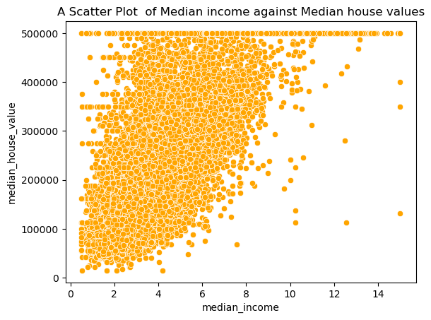

```python
import matplotlib.pyplot as plt
import seaborn as sns

sns.scatterplot(x="median_income", y="median_house_value", data=df, color='orange')
plt.title("A Scatter Plot  of Median income against Median house values")
plt.show()
```

The key observations observed in this scatter plot are correlation and ceiling effect. \ Correlation: There seems to be a positive correlation between median income and median house value. As income increases, house values also tend to increase, though the relationship isn't perfectly linear. but it is almost linear. \ Ceiling Effect: The house values appear to be capped at 500,000 (a maximum threshold in the dataset). This ceiling effect results from a limit imposed in the dataset. I have preprocessed the data to filter out records with median_house_value = 500001 since it seems to be a cap for the median_house_value. \ Some of the insights on linear regression are: \ Based on the scatter plot, a linear regression analysis could provide valuable insights into the relationship between median income and median house values. There appears to be a positive correlation between median income and median house values, suggesting that as median income increases, median house values tend to increase as well.

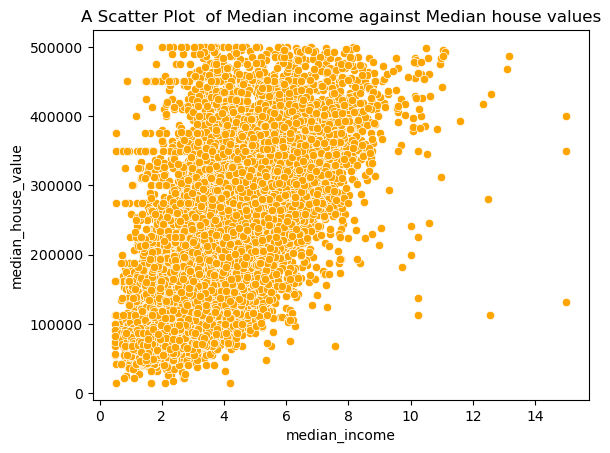

```python
housing_preprocessed = df[df.median_house_value != 500001]
sns.scatterplot(x="median_income", y="median_house_value", data=housing_preprocessed, color='orange')
plt.title("A Scatter Plot  of Median income against Median house values")
plt.show()
```

[figure not shown]

```python
sns.scatterplot(x="population", y="median_house_value", data=df, color='green')
plt.title("A Scatter Plot  of Median income against Population")
plt.show()
```

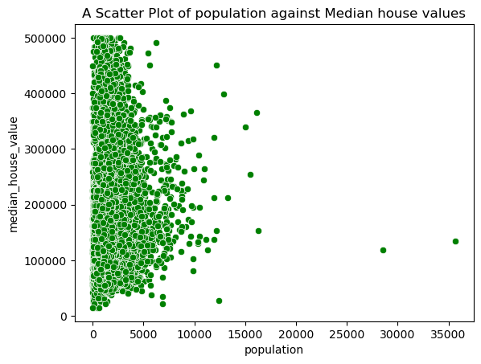

```python
housing_preprocessed2 = df[df.median_house_value != 500001]
sns.scatterplot(x="population", y="median_house_value", data=housing_preprocessed2, color='green')
plt.title("A Scatter Plot of population against Median house values")
plt.show()
```

[figure not shown]

```python
sns.scatterplot(x="households", y="median_house_value", data=df, color='blue')
plt.title("A Scatter Plot  of Median income against Number of households")
plt.show()
```

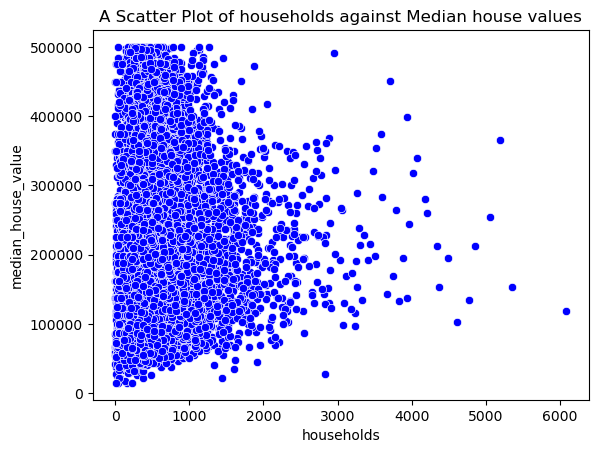

```python
housing_preprocessed3 = df[df.median_house_value != 500001]
sns.scatterplot(x="households", y="median_house_value", data=housing_preprocessed3, color='blue')
plt.title("A Scatter Plot of households against Median house values")
plt.show()
```

Based on the above, describe the 4 variables used in this lab. Observations such as their meaning, range and additional characteristics that you notice. This should be concise, and relevant (1 point).

MedianHousevalue: Median house value for households within a block (measured in US Dollars). This is the dependent variable we're focusing on for predicting housing prices. It ranges from $14,999 to $500,001 (due to a capping at 500,001) and its Mean is $206,856. The distribution is likely skewed, with many data points closer to the lower and middle house price ranges and a smaller number near the upper cap. \ medianIncome: Median income for households within a block of houses (measured in tens of thousands of US Dollars). It ranges from 0.4999 (possibly an outlier or data entry error) to 15.0001 and its Mean is 3.87 (roughly $38,700 when considering income in units of tens of thousands). A major characteristic of this feature is that has a strong correlation with house value prices. \ Population: Total number of people residing within a block. It ranges from 3(indicating very small block groups or potential data entry issues) to 35,682 and its Mean is 1,425. An observation here is that The population ranges dramatically, from as few as 3 people to over 35,000. This could suggest the inclusion of both urban and rural block groups. \ households: Total number of households, a group of people residing within a home unit, for a block. It ranges from 1 to 6,082 and its Mean is 499. Similar to population, this feature displays considerable variation, which could indicate different urban, suburban, and rural characteristics across block groups.

### Running the three linear regressions (fitting)

```python
from sklearn import linear_model
from sklearn.metrics import mean_squared_error, mean_absolute_error
```

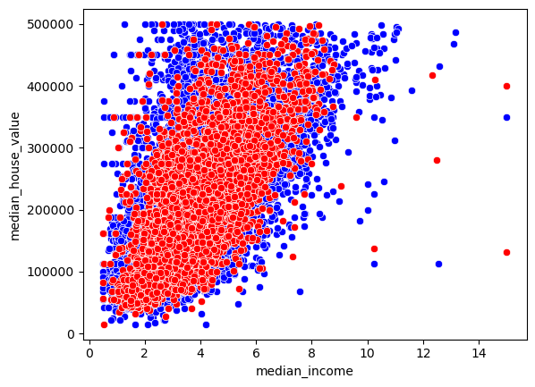

```python
#Running a Linear Regression to predict my dependent variable(median_house_value) from my independent variable(median_income)
train_size = int(len(housing_preprocessed) * 0.8)
train = housing_preprocessed[:train_size]
test = housing_preprocessed[train_size:]

sns.scatterplot(x="median_income", y="median_house_value", data=train, color="blue")
sns.scatterplot(x="median_income", y="median_house_value", data=test, color="red")
```

```python
model1 = linear_model.LinearRegression()
model1.fit(X=train[["median_income"]], y=train[["median_house_value"]])
```

```
LinearRegression()
```

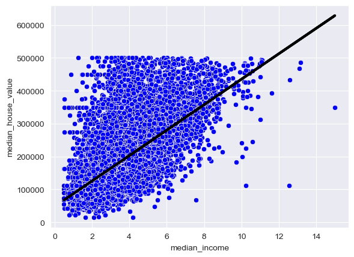

```python
# plot the regression line against the training data
sns.scatterplot(x="median_income", y="median_house_value", data=train, color="blue")
plt.plot(train[["median_income"]], model1.predict(train[["median_income"]]), color="black", linewidth=3)
sns.set_style("darkgrid")
plt.show()
```

```python
# print coefficients
intercept1 = model1.intercept_
coef1 = model1.coef_
print("Intercept:", intercept1)
print("Coefficients:" ,coef1)

# print the MSE and MAE on the test set
mse_value1 = mean_squared_error(test[['median_house_value']], model1.predict(test[['median_income']]))
print("Mean squared error:", mse_value1)

mae_value1 = mean_absolute_error(test[['median_house_value']], model1.predict(test[['median_income']]))
print("Mean Absolute error:", mae_value1)
```

```
Intercept: [48204.53436817]
Coefficients: [[38702.97233842]]
Mean squared error: 5831038297.419374
Mean Absolute error: 59961.60099129186
```

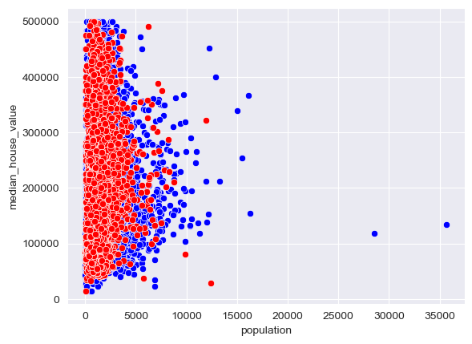

```python
#Running a Linear Regression to predict my dependent variable(median_house_value) from my independent variable(population)
train_size2 = int(len(housing_preprocessed2) * 0.8)
train2 = housing_preprocessed2[:train_size2]
test2 = housing_preprocessed2[train_size2:]

sns.scatterplot(x="population", y="median_house_value", data=train2, color="blue")
sns.scatterplot(x="population", y="median_house_value", data=test2, color="red")
```

```python
model2 = linear_model.LinearRegression()
model2.fit(X=train2[["population"]], y=train2[["median_house_value"]])
```

```
LinearRegression()
```

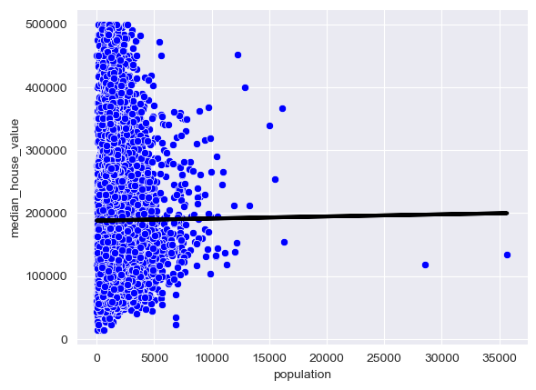

```python
sns.scatterplot(x="population", y="median_house_value", data=train2, color="blue")
plt.plot(train2[["population"]], model2.predict(train2[["population"]]), color="black", linewidth=3)
sns.set_style("darkgrid")
plt.show()
```

```python
# print coefficients
intercept2 = model2.intercept_
coef2 = model2.coef_
print("Intercept:", intercept2)
print("Coefficients:" ,coef2)

# print the MSE and MAE on the test set
mse_value2 = mean_squared_error(test2[['median_house_value']], model2.predict(test2[['population']]))
print("Mean squared error:", mse_value2)

mae_value2 = mean_absolute_error(test2[['median_house_value']], model2.predict(test2[['population']]))
print("Mean Absolute error:", mae_value2)
```

```
Intercept: [188081.58862584]
Coefficients: [[0.32862973]]
Mean squared error: 10863782849.783281
Mean Absolute error: 85178.9089807831
```

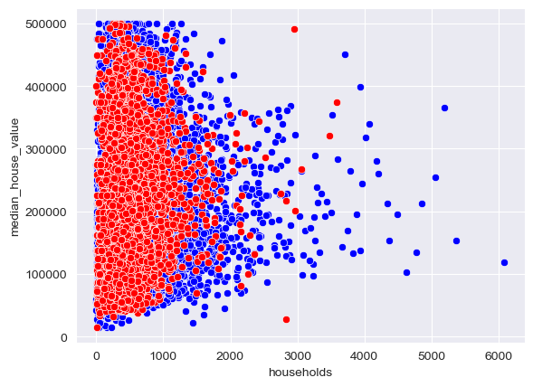

```python
#Running a Linear Regression to predict my dependent variable(median_house_value) from my independent variable(households)
train_size3 = int(len(housing_preprocessed3) * 0.8)
train3 = housing_preprocessed3[:train_size3]
test3 = housing_preprocessed3[train_size3:]

sns.scatterplot(x="households", y="median_house_value", data=train3, color="blue")
sns.scatterplot(x="households", y="median_house_value", data=test3, color="red")
```

```python
model3 = linear_model.LinearRegression()
model3.fit(X=train3[["households"]], y=train3[["median_house_value"]])
```

```
LinearRegression()
```

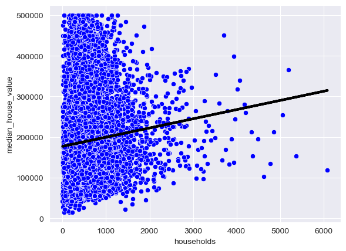

```python
sns.scatterplot(x="households", y="median_house_value", data=train3, color="blue")
plt.plot(train3[["households"]], model3.predict(train3[["households"]]), color="black", linewidth=3)
sns.set_style("darkgrid")
plt.show()
```

```python
intercept3 = model3.intercept_
coef3 = model3.coef_
print("Intercept:", intercept3)
print("Coefficients:" ,coef3)

# print the MSE and MAE on the test set
mse_value3 = mean_squared_error(test3[['median_house_value']], model3.predict(test3[['households']]))
print("Mean squared error:", mse_value3)

mae_value3 = mean_absolute_error(test3[['median_house_value']], model3.predict(test3[['households']]))
print("Mean Absolute error:", mae_value3)
```

```
Intercept: [177147.28853835]
Coefficients: [[22.62572591]]
Mean squared error: 10759278800.526697
Mean Absolute error: 84503.14723508563
```

### A single table for all three linear regressions, provide per regression model the intercept, slope, MSE and MAE

```python
summarytable = {
    'Model': ['Model1', 'Model2', 'Model3'],
    'Mean Absolute Error': [mae_value1, mae_value3,mae_value3],
    'Mean Squared Error': [mse_value1,mse_value2,mse_value3],
    'Coefficients':[coef1, coef2, coef3],
    'Intercept': [intercept1, intercept2, intercept3]
}

result_df = pd.DataFrame(summarytable)
result_df
```

[output not shown]

### Summary

Model 1 appears to be the best-performing model based on the given metrics. It has the lowest MAE and MSE, suggesting that it provides more accurate predictions. However, further analysis, including examining the coefficients, and evaluating the model's performance on new data, is recommended to gain a more comprehensive understanding of its effectiveness. \ In Model 1 The coefficient is significantly larger than in other models, indicating a strong relationship between the predictor and the target variable. In Model 2 and Model 3, the coefficients are smaller, suggesting a weaker relationship. \ Based on MAE and MSE, Model 1 has the best goodness-of-fit. It has the lowest MAE and MSE, suggesting that its predictions are closer to the actual values on average.